# Personal-academic Project

# Unsupervised methods in machine learning

Anton Barrera Mora (me@antonio-barrera.cyou)

March 2023

# 1 Introduction

## 1.1 Presentation

In this project we will work with unsupervised machine learning models, with special emphasis on the modification of parameters to refine the results.

## 1.2 Objetives

The objectives are generation, interpretation, and evaluation of a k-means clustering model and a DBSCAN model. In doing so, we will not overlook the phases of data preparation, model quality, and initial knowledge extraction.

# 2 Example 1

## 2.1 k-means aggregation method with real data

We will use the ‘Hawks’ dataset, which is part of the ‘Stat2Data’ package that includes datasets used in the book ‘Stat2: Building Models for a World of Data’ by Cannon et al. (2013a)

The dataset originated from a research project as referenced earlier “Minería de Datos: PEC2” (2023) where measurements were taken on various characteristics of captured and subsequently released hawks. The data source is not clearly specified or documented in the book or on the Oberlin University website “Digital Commons at Oberlin” (n.d.) . The dataset package is used in the aforementioned book to provide an example of nonparametric statistics Cannon et al. (2013a), p. 86. It is widely used in statistics courses.

We have selected this dataset because of its potential for unsupervised data mining algorithms. The numerical variables on which we will be based are Wing, Weight, Culmen, Hallux

```r
if (!require('Stat2Data')) install.packages('Stat2Data')
library(Stat2Data)
data("Hawks")
summary(Hawks)
```

```
##      Month             Day             Year       CaptureTime   ReleaseTime
##  Min.   : 8.000   Min.   : 1.00   Min.   :1992   11:35  : 14          :842
##  1st Qu.: 9.000   1st Qu.: 9.00   1st Qu.:1995   13:30  : 14   11:00  :  2
##  Median :10.000   Median :16.00   Median :1999   11:45  : 13   11:35  :  2
##  Mean   : 9.843   Mean   :15.74   Mean   :1998   12:10  : 13   12:05  :  2
##  3rd Qu.:10.000   3rd Qu.:23.00   3rd Qu.:2001   14:00  : 13   12:50  :  2
##  Max.   :11.000   Max.   :31.00   Max.   :2003   13:05  : 12   13:32  :  2
##                                                  (Other):829   (Other): 56
##       BandNumber  Species  Age     Sex          Wing           Weight
##            :  2   CH: 70   A:224    :576   Min.   : 37.2   Min.   :  56.0
##  1142-09240:  1   RT:577   I:684   F:174   1st Qu.:202.0   1st Qu.: 185.0
##  1142-09241:  1   SS:261           M:158   Median :370.0   Median : 970.0
##  1142-09242:  1                            Mean   :315.6   Mean   : 772.1
##  1142-18229:  1                            3rd Qu.:390.0   3rd Qu.:1120.0
##  1142-19209:  1                            Max.   :480.0   Max.   :2030.0
##  (Other)   :901                            NA's   :1       NA's   :10
##      Culmen         Hallux            Tail        StandardTail
##  Min.   : 8.6   Min.   :  9.50   Min.   :119.0   Min.   :115.0
##  1st Qu.:12.8   1st Qu.: 15.10   1st Qu.:160.0   1st Qu.:162.0
##  Median :25.5   Median : 29.40   Median :214.0   Median :215.0
##  Mean   :21.8   Mean   : 26.41   Mean   :198.8   Mean   :199.2
##  3rd Qu.:27.3   3rd Qu.: 31.40   3rd Qu.:225.0   3rd Qu.:226.0
##  Max.   :39.2   Max.   :341.40   Max.   :288.0   Max.   :335.0
##  NA's   :7      NA's   :6                        NA's   :337
##      Tarsus        WingPitFat        KeelFat           Crop
##  Min.   :24.70   Min.   :0.0000   Min.   :0.000   Min.   :0.0000
##  1st Qu.:55.60   1st Qu.:0.0000   1st Qu.:2.000   1st Qu.:0.0000
##  Median :79.30   Median :1.0000   Median :2.000   Median :0.0000
##  Mean   :71.95   Mean   :0.7922   Mean   :2.184   Mean   :0.2345
##  3rd Qu.:87.00   3rd Qu.:1.0000   3rd Qu.:3.000   3rd Qu.:0.2500
##  Max.   :94.00   Max.   :3.0000   Max.   :4.000   Max.   :5.0000
##  NA's   :833     NA's   :831      NA's   :341     NA's   :343
```

The ‘summary()’ function in the R language provides a basic statistical summary of variables in a dataset. For numeric variables, it returns statistics such as minimum, first quartile (Q1), median, mean, third quartile (Q3), and maximum. For categorical variables, it returns a frequency table.

We will complete a first analysis using the head() function that will allow us to obtain a snapshot of the first records in the database:

```r
head(Hawks)
```

```
##   Month Day Year CaptureTime ReleaseTime  BandNumber Species Age Sex Wing
## 1     9  19 1992       13:30               877-76317      RT   I      385
## 2     9  22 1992       10:30               877-76318      RT   I      376
## 3     9  23 1992       12:45               877-76319      RT   I      381
## 4     9  23 1992       10:50               745-49508      CH   I   F  265
## 5     9  27 1992       11:15              1253-98801      SS   I   F  205
## 6     9  28 1992       11:25             1207-55910       RT   I      412
##   Weight Culmen Hallux Tail StandardTail Tarsus WingPitFat KeelFat Crop
## 1    920   25.7   30.1  219           NA     NA         NA      NA   NA
## 2    930     NA     NA  221           NA     NA         NA      NA   NA
## 3    990   26.7   31.3  235           NA     NA         NA      NA   NA
## 4    470   18.7   23.5  220           NA     NA         NA      NA   NA
## 5    170   12.5   14.3  157           NA     NA         NA      NA   NA
## 6   1090   28.5   32.2  230           NA     NA         NA      NA   NA
```

From the analysis of the attributes, we obtain the following information about the variables:

- Age: Age of the hawk - young (I) or adult (A) -.
- Species: Species of the hawk - Cooper’s Hawk (CH), Red-Tailed Hawk (RT), or Sharp-Shinned Hawk (SS) -.
- Sex: Gender of the hawk - male (M) or female (F) -.
- Wing: Wing length of the hawk - in millimeters -.
- Weight: Weight of the hawk - in grams -.
- Culmen: Culmen length of the hawk’s beak - in millimeters -.
- Hallux: Hallux length of the hawk’s claw - in millimeters -.

At this point, there are other variables or columns in the dataset that are irrelevant for the requirements of this work, so we will filter them later.

Additionally, thanks to the information provided by the summary function, we know the following:

1. The ‘BandNumber’ variable contains unique records that help identify specific individuals and can be used as a primary key. We observe that there are two blank records without a number, so we will opt to create a new numeric variable.
2. The ‘Wing’ variable contains 1 infinite or NA value. Considering that there are noticeable size differences depending on the age and species of the specimens, but this data does not correspond to a continuous variable but a discrete one, we will assign the mean wing size based on the age of the specific specimen and its species.
3. The ‘Weight’ variable also has 10 instances with NA values. We will apply the same criterion as the ‘Wing’ variable. That is, we will assign the mean weight corresponding to its age group to each record.
4. The ‘Culmen’ variable contains 7 records with NA values. We will apply the previously described criterion of assigning means according to age.
5. The ‘Hallux’ variable also contains 6 NA records to which we will apply the corrective policies described earlier.

We will select the dataset of interest from the current dataset.

```r
# We select only the variables that we are interested in working with.

hawks_select <- Hawks %>% select(BandNumber, Year, Month, Day, Species, Age, Wing, Weight, Culmen, Hallux)
```

Point 1. We correct the primary key according to the parameters set in the plan:

```r
# creating a new record with numbers from 1 to the total number of rows in the dataset.
hawks_select$Num_id <- 1:nrow(hawks_select)

# Verifying that all values are unique
if (length(unique(hawks_select$Num_id)) == nrow(hawks_select)) {
  cat("The values in the column 'Num_ID' are unique.\n")
} else {
  cat("The values in the column 'Num_ID' are NOT unique.\n")
}
```

```
## The values in the column 'Num_ID' are unique.
```

```r
hawks_select <- subset(hawks_select, select = -BandNumber)
```

Point 2. We are going to correct the variable Wing that had a record with no value:

```r
# El atributo tiene un valor NA, vamos a calcular una media condicional:

media_alas_especie_edad <- aggregate(Wing ~ Species + Age, data = hawks_select, FUN = function(x) mean(x, na.rm= TRUE))

# Calculamos las medias de la columna 'Wing' para cada especie y edad, excluyendo los valores NA

# Imputamos el valor faltante en la columna 'Wing' segun la especie y la edad
# iteramos sobre cada registro usdando un bucle for empezando por 1 hasta el valor del numero de filas
# usando 'nrow'

for (i in 1:nrow(hawks_select)) {
  # Si el valor de 'Wing' que estamos buscando es NA, buscamos la media que corresponde a la especie y edad
  if (is.na(hawks_select$Wing[i])) {
    # Filtramos el 'data.frame' según la especie y edad
    media_especie_edad <- media_alas_especie_edad$Wing[media_alas_especie_edad$Species == hawks_select$Species[i] & media_alas_especie_edad$Age == hawks_select$Age[i]]
    # imputamos la media que corresponda
    hawks_select$Wing[i] <- media_especie_edad
  }
}

# Verificamos que no haya valores NA en la columna
if (!any(is.na(hawks_select$Wing))) {
  cat("Todos los valores NA en la columna 'Wing' han sido correctamente imputados")
} else {
  cat("Aun quedan valores NA en la columna 'Wing'. \n")
}
```

```
## Todos los valores NA en la columna 'Wing' han sido correctamente imputados
```

Point 3. We go on to correct the NA values in the ‘Weight’ table using the same method as above. That is, we impute the mean according to age and species:

```r
# El atributo tiene diez registros con NA, vamos a calcular una media condicional:

media_peso_especie_edad <- aggregate(Weight ~ Species + Age, data = hawks_select, FUN = function(x) mean(x, na.rm= TRUE))

# Calculamos las medias de la columna 'Weight' para cada especie y edad, excluyendo los valores NA

# Imputamos el valor faltante en la columna 'Weight' según la especie-edad
# iteramos sobre cada registro usando un bucle 'for' empezando por 1 hasta el valor del numero de filas
# empleando 'nrow'

for (i in 1:nrow(hawks_select)) {
  # Si el valor de 'Weight' que estamos buscando es NA, buscamos la media que corresponde a la especie y edad
  if (is.na(hawks_select$Weight[i])) {
    # Filtramos el 'data.frame' según la especie y edad
    media_especie_edad <- media_peso_especie_edad$Weight[media_peso_especie_edad$Species == hawks_select$Species[i] & media_peso_especie_edad$Age == hawks_select$Age[i]]
    # imputamos la media que corresponda al registro NA
    hawks_select$Weight[i] <- media_especie_edad
  }
}

# Verificamos que no haya valores NA en la columna
if (!any(is.na(hawks_select$Weight))) {
  cat("Todos los valores NA en la columna 'Weight' han sido correctamente imputados")
} else {
  cat("Aun quedan valores NA en la columna 'Weight'. \n")
}
```

```
## Todos los valores NA en la columna 'Weight' han sido correctamente imputados
```

Point 4. The variable ‘Culmen’ contains 7 NA records which we will correct using the same procedure as above, i.e. calculating the mean of the beak dimensions according to age > and species.

```r
# El atributo tiene 7 registros NAs, vamos a calcular una media condicional:

media_pico_especie_edad <- aggregate(Culmen ~ Species + Age, data = hawks_select, FUN = function(x) mean(x, na.rm= TRUE))

# Calculamos las medias de la columna 'Culmen' para cada especie y edad, excluyendo los valores NA

# Imputamos el valor faltante en la columna 'Culmen' según la especie-edad
# iteramos sobre cada registro usando un bucle 'for' empezando por 1 hasta el valor del numero de filas
# empleando 'nrow'

for (i in 1:nrow(hawks_select)) {
  # Si el valor de 'Culmen' que estamos buscando es NA, buscamos la media que corresponde a la especie y edad
  if (is.na(hawks_select$Culmen[i])) {
    # Filtramos el 'data.frame' según la especie y edad
    media_especie_edad <- media_pico_especie_edad$Culmen[media_pico_especie_edad$Species == hawks_select$Species[i] & media_pico_especie_edad$Age == hawks_select$Age[i]]
    # imputamos la media que corresponda al registro NA
    hawks_select$Culmen[i] <- media_especie_edad
  }
}

# Verificamos que no haya valores NA en la columna
if (!any(is.na(hawks_select$Culmen))) {
  cat("Todos los valores NA en la columna 'Culmen' han sido correctamente imputados")
} else {
  cat("Aun quedan valores NA en la columna 'Culmen'. \n")
}
```

```
## Todos los valores NA en la columna 'Culmen' han sido correctamente imputados
```

Point 5. The variable ‘Hallux’ contains another suitable number of NA records. We apply the corrective policies previously implemented:

```r
# El atributo tiene 6 registros NAs, vamos a calcular una media condicional.
# Calculamos las medias de la columna 'Hallux' para cada especie y edad

media_espolon_especie_edad <- aggregate(Hallux ~ Species + Age, data = hawks_select, FUN = function(x) mean(x, na.rm= TRUE))


# Imputamos el valor faltante en la columna 'Hallux' según la especie-edad, iteramos sobre cada registro # usando un bucle 'for' empezando por 1 hasta el valor del numero de filas empleando 'nrow'

for (i in 1:nrow(hawks_select)) {
  # Si el valor de 'Hallux' que estamos buscando es NA, buscamos la media que corresponde a la especie y edad
  if (is.na(hawks_select$Hallux[i])) {
    # Filtramos el 'data.frame' según la especie y edad
    media_especie_edad <- media_espolon_especie_edad$Hallux[media_espolon_especie_edad$Species == hawks_select$Species[i] & media_espolon_especie_edad$Age == hawks_select$Age[i]]
    # imputamos la media que corresponda al registro NA
    hawks_select$Hallux[i] <- media_especie_edad
  }
}

# Verificamos que no haya valores NA en la columna
if (!any(is.na(hawks_select$Hallux))) {
  cat("Todos los valores NA en la columna 'Hallux' han sido correctamente imputados")
} else {
  cat("Aun quedan valores NA en la columna 'Hallux'. \n")
}
```

```
## Todos los valores NA en la columna 'Hallux' han sido correctamente imputados
```

Before going on to check the tables and variables created and modified, let’s round to one decimal place.

```r
# Copia de seguridad

hawks_select_copy <- hawks_select

# Redondeamos a un decimal en la tabla 'hawks_select':

hawks_select$Weight <- round(hawks_select$Weight, 1)
hawks_select$Wing <- round(hawks_select$Wing, 1)
hawks_select$Culmen <- round(hawks_select$Culmen, 1)
hawks_select$Hallux <- round(hawks_select$Hallux, 1)

# Redondeamos a dos decimales en la tabla 'media_alas_especie_X'(alas, espolon, peso, pico)
media_alas_especie_edad$Wing <- round(media_alas_especie_edad$Wing, 1)
media_espolon_especie_edad$Hallux <- round(media_espolon_especie_edad$Hallux, 1)
media_peso_especie_edad$Weight <- round(media_peso_especie_edad$Weight, 1)
media_pico_especie_edad$Culmen <- round(media_pico_especie_edad$Culmen, 1)
```

Based on the summary() performed at the beginning, there seem to be outliers in the records, aside from the issues with infinite or ‘NA’ values. At first, we may be tempted to impute these apparent outliers or attribute the variability to age differences. Age is the trap in this database. It can greatly influence physiological measurements and may be, as we maintain, the main cause of variability.

However, clearly from the results of the summary() function, we can see extreme values in the ‘Hallux’ variable. A minimum of 9.50 and a maximum of 341.40, unless some of the analyzed specimens are prehistoric birds, doesn’t seem very normal. And as for the ‘Wing’ variable, we can make the same assertion, although the values are less extreme.

Therefore, we will need to identify outliers beyond the normal range using the interquartile range or IQR. It is a statistical dispersion measure that represents the difference between the third quartile (Q3) and the first quartile (Q1). Quartiles divide a data distribution into four equal parts.

The first quartile is the value below which 25% of the data lies, the third quartile is the value below which 75% of the data lies, and the IQR represents the range where half of the data lies. Outliers are therefore those that are above or below Q1 or Q3 in that distribution.

In our case, we need to expand the margins, meaning extend the range beyond Q1 and Q3, so multiply by +- 1.5. The lower limit will be negative, so unless it’s a typographical error, we doubt that the claw or spur has a negative length. However, we don’t know what the minimum is because we are talking about birds in a developmental period.

This allow us to observe the lower and upper limits of each variable of interest or those we suspected to have issues. Also include the other variables to ensure that there are no problems. In theory, there should be no infinite values, so the use of the na.rm() function to remove them will not be necessary. Subsequently, proceding to represent them in box plots.

```r
print("Aplicando IQR")
```

```
## [1] "Aplicando IQR"
```

```r
## Aplicando IQR ##
###################

# Aplicamos IQR #
#################
wing_iqr <- IQR(hawks_select$Wing)
hallux_iqr <- IQR(hawks_select$Hallux)
weight_iqr <- IQR(hawks_select$Weight)
culmen_iqr <- IQR(hawks_select$Culmen)

# Establecemos los limites #
############################
# Nota: El limite inferior queda en negativo, asi que salvo error tipográfico, dudamos que la garra o espolon sea negativa. Ahora bien no sabemos cual es el minimo porque estamos hablando de aves en desarrollo.

# Variable 'wing'
wing_limite_bajo <- quantile(hawks_select$Wing, 0.25) -1.5 * wing_iqr
wing_limite_alto <- quantile(hawks_select$Wing, 0.75) + 1.5 * wing_iqr
# Variable 'Hallux'
hallux_limite_bajo <- quantile(hawks_select$Hallux, 0.25) -1.5 * hallux_iqr
hallux_limite_alto <- quantile(hawks_select$Hallux, 0.75) +1.5 * hallux_iqr
# Variable 'Weight'
weight_limite_bajo <- quantile(hawks_select$Weight, 0.25) -1.5 * weight_iqr
weight_limite_alto <- quantile(hawks_select$Weight, 0.75) +1.5 * weight_iqr
# Variable 'Culmen'
culmen_limite_bajo <- quantile(hawks_select$Culmen, 0.25) -1.5 * culmen_iqr
culmen_limite_alto <- quantile(hawks_select$Culmen, 0.75) +1.5 * culmen_iqr


# identificamos los valores atipicos en cada una de las variables:
wing_outliers <- hawks_select$Wing[hawks_select$Wing < wing_limite_bajo | hawks_select$Wing > wing_limite_alto]

hallux_outliers <- hawks_select$Hallux[hawks_select$Hallux < hallux_limite_bajo | hawks_select$Hallux > hallux_limite_alto]

weight_outliers <- hawks_select$Weight[hawks_select$Weight < weight_limite_bajo | hawks_select$Weight > weight_limite_alto]

culmen_outliers <- hawks_select$Culmen[hawks_select$Culmen < culmen_limite_bajo | hawks_select$Culmen > culmen_limite_alto]

## Visualizamos los valores fuera de rango, de haberlos:
########################################################

print("Visualizamos los valores fuera de rango")
```

```
## [1] "Visualizamos los valores fuera de rango"
```

```r
# Convertimos los vectores en 'data.frames'#
hallux_outliers_df <- data.frame(hallux_outliers)
weight_outliers_df <- data.frame(weight_outliers)
wing_outliers_df <- data.frame(wing_outliers)
culmen_outliers_df <- data.frame(culmen_outliers)

# Imprimimos tablas en el documento
kable(hallux_outliers_df, caption = "Outliers en 'Hallux'")
```

Outliers en ‘Hallux’

| hallux_outliers |
| --- |
| 101.0 |
| 308.0 |
| 341.4 |
| 143.0 |
| 82.8 |
| 121.0 |
| 130.0 |

```r
kable(weight_outliers_df, caption = "Outliers en 'Weight'")
```

Outliers en ‘Weight’

| weight_outliers |
| --- |

```r
kable(wing_outliers_df, caption = "Outliers en 'Wing'")
```

Outliers en ‘Wing’

| wing_outliers |
| --- |

```r
kable(culmen_outliers_df, caption = "Outliers en 'Culmen'")
```

Outliers en ‘Culmen’

| culmen_outliers |
| --- |

We proceed to the graphical representation, but considering that the only outliers are in the variable ‘hallux’:

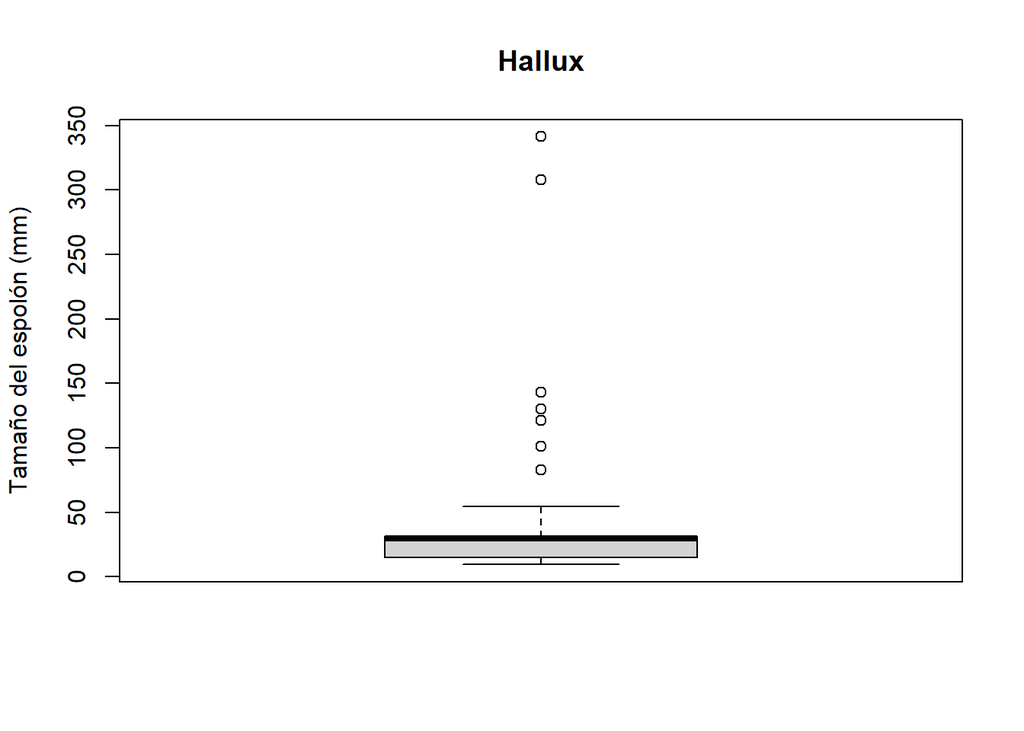

```r
# Representación de la variable 'Hallux'
boxplot(hawks_select$Hallux, main = "Hallux", ylab = "Tamaño del espolón (mm)", outline = TRUE)
```

The graphical representation shows us that, indeed, we have 7 values outside the dispersion ranges. At this point, we must decide what to do with these values and we choose to impute the species- and age-dependent mean to them:

```r
print("imputamos las medias en 'Hallux' a outliers segun especie y edad")
```

```
## [1] "imputamos las medias en 'Hallux' a outliers segun especie y edad"
```

```r
for (i in 1:nrow(hawks_select)) {
  # Si el valor de 'Hallux' que estamos buscando es superior a 55.9, buscamos la media que    corresponde a la especie y edad. No es necesario buscar en el rango inferior porque sabemos que todos los valores son superiores a 55.9
  if (hawks_select$Hallux[i] > hallux_limite_alto) {
    # Filtramos el 'data.frame' según la especie y edad
    media_especie_edad <- media_espolon_especie_edad$Hallux[media_espolon_especie_edad$Species == hawks_select$Species[i] & media_espolon_especie_edad$Age == hawks_select$Age[i]]
    # imputamos la media que corresponda al registro NA
    hawks_select$Hallux[i] <- media_especie_edad
  }
}

# Verificamos que no haya valores NA en la columna
if (!any(hawks_select$Hallux[i] > hallux_limite_alto)) {
  cat("Todos los valores Outliers en la columna 'Hallux' han sido correctamente imputados")
} else {
  cat("Aun quedan valores Outliers en la columna 'Hallux'. \n")
}
```

```
## Todos los valores Outliers en la columna 'Hallux' han sido correctamente imputados
```

The operation appears to have been successful, we repeat with the box chart:

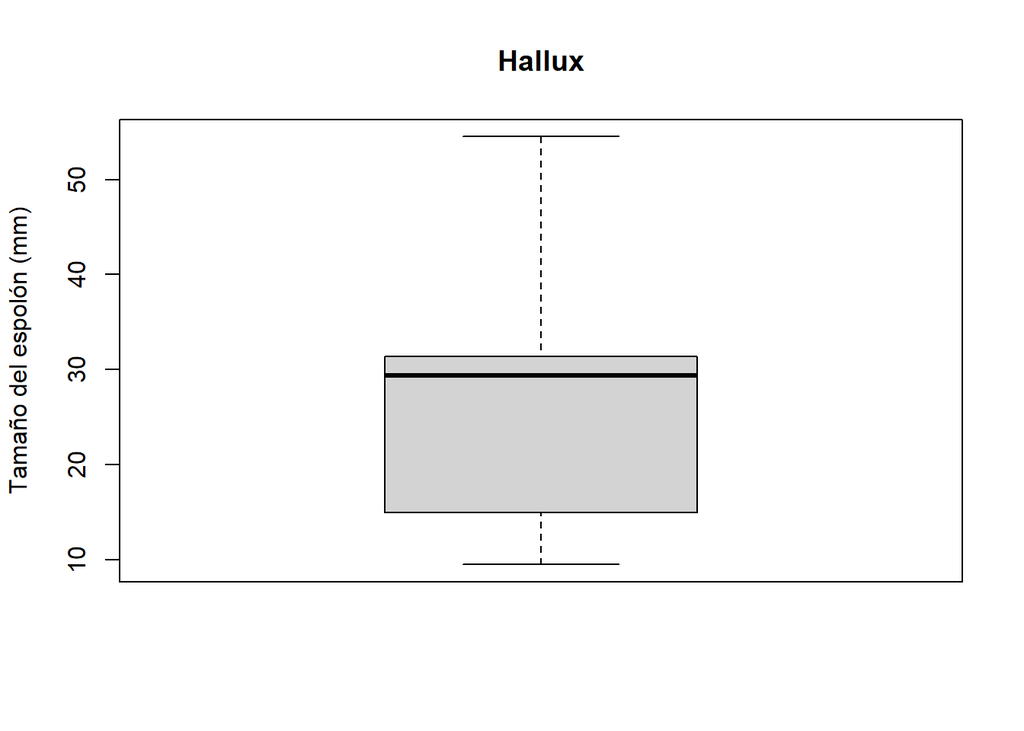

```r
# Representación de la variable 'Hallux' en busca de confirmar que no quedan outliers:

boxplot(hawks_select$Hallux, main = "Hallux", ylab = "Tamaño del espolón (mm)", outline = TRUE)
```

Indeed, no out-of-range values left in the variable.

### 2.1.1 Table Integrity revision

```r
summary(hawks_select)
```

```
##       Year          Month             Day        Species  Age
##  Min.   :1992   Min.   : 8.000   Min.   : 1.00   CH: 70   A:224
##  1st Qu.:1995   1st Qu.: 9.000   1st Qu.: 9.00   RT:577   I:684
##  Median :1999   Median :10.000   Median :16.00   SS:261
##  Mean   :1998   Mean   : 9.843   Mean   :15.74
##  3rd Qu.:2001   3rd Qu.:10.000   3rd Qu.:23.00
##  Max.   :2003   Max.   :11.000   Max.   :31.00
##       Wing           Weight           Culmen          Hallux
##  Min.   : 37.2   Min.   :  56.0   Min.   : 8.60   Min.   : 9.50
##  1st Qu.:202.0   1st Qu.: 185.0   1st Qu.:12.78   1st Qu.:15.00
##  Median :370.0   Median : 970.0   Median :25.50   Median :29.40
##  Mean   :315.6   Mean   : 770.5   Mean   :21.79   Mean   :25.21
##  3rd Qu.:390.0   3rd Qu.:1120.0   3rd Qu.:27.30   3rd Qu.:31.40
##  Max.   :480.0   Max.   :2030.0   Max.   :39.20   Max.   :54.50
##      Num_id
##  Min.   :  1.0
##  1st Qu.:227.8
##  Median :454.5
##  Mean   :454.5
##  3rd Qu.:681.2
##  Max.   :908.0
```

No infinite values, and the means, although quite disparate as in the case of ‘wing’ - considering that it does not discriminate developing birds - do not contain extreme values.

Continue examining the table, now analyzing the variables using the name() function.

```r
# Analizamos con `name()` las variables:
names(hawks_select)
```

```
##  [1] "Year"    "Month"   "Day"     "Species" "Age"     "Wing"    "Weight"
##  [8] "Culmen"  "Hallux"  "Num_id"
```

```r
# Analizamos con `head()`

head(hawks_select, 3)
```

```
##   Year Month Day Species Age Wing Weight Culmen Hallux Num_id
## 1 1992     9  19      RT   I  385    920   25.7   30.1      1
## 2 1992     9  22      RT   I  376    930   26.8   32.2      2
## 3 1992     9  23      RT   I  381    990   26.7   31.3      3
```

Next we will analyse the structure with the str() function which gives us a more complete overview of the table structure:

```r
# Realizamos un resumen estadistico de todas la variables:

str(hawks_select)
```

```
## 'data.frame':    908 obs. of  10 variables:
##  $ Year   : int  1992 1992 1992 1992 1992 1992 1992 1992 1992 1992 ...
##  $ Month  : int  9 9 9 9 9 9 9 9 9 9 ...
##  $ Day    : int  19 22 23 23 27 28 28 29 29 30 ...
##  $ Species: Factor w/ 3 levels "CH","RT","SS": 2 2 2 1 3 2 2 2 2 2 ...
##  $ Age    : Factor w/ 2 levels "A","I": 2 2 2 2 2 2 2 1 1 2 ...
##  $ Wing   : num  385 376 381 265 205 412 370 375 412 405 ...
##  $ Weight : num  920 930 990 470 170 1090 960 855 1210 1120 ...
##  $ Culmen : num  25.7 26.8 26.7 18.7 12.5 28.5 25.3 27.2 29.3 26 ...
##  $ Hallux : num  30.1 32.2 31.3 23.5 14.3 32.2 30.1 30 31.3 30.2 ...
##  $ Num_id : int  1 2 3 4 5 6 7 8 9 10 ...
```

We observe that we have 908 records in 10 variables. At this point, we do not consider changing the measurement scale to kilograms for the ‘Weight’ variable, which seems more appropriate, especially for the juvenile bird population. We also do not consider any changes necessary in the types of variables present in the table.

Regarding the “additional tables” that contain the means of different physiological measurements for different species based on their age, we do not believe it is necessary to analyze them using any R function, as they are highly summarized tables with 6 records and 3 variables.

### 2.1.2 Inventory

At this point, our dataset consists of:

Table ‘hawks_select’ with all the relevant variables for the analysis and with the cleaning process applied.

Additional tables with means of wing length, hallux size, weight, and culmen length in relation to species and age. These tables contain 6 records and 3 variables each.

### 2.1.3 Distribution of variables in the ‘hawks_select’ table.

- Histograms.

```r
# Histogramas para variables numéricas ##
#########################################

# Histograma para 'Wing'
print("Distribucion del tamaño de las alas")
```

```
## [1] "Distribucion del tamaño de las alas"
```

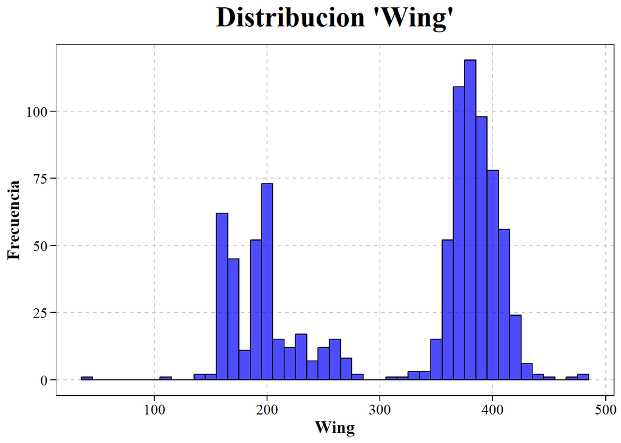

```r
ggplot(hawks_select, aes(x= Wing)) +
  geom_histogram(binwidth = 10, color = "black", fill= "blue", alpha= 0.7) +
  mi_tema() +
  labs(title = "Distribucion 'Wing'", x = "Wing", y = "Frecuencia")
```

```r
# Histograma paea 'Weight'
print("Distribucion del tamaño del peso")
```

```
## [1] "Distribucion del tamaño del peso"
```

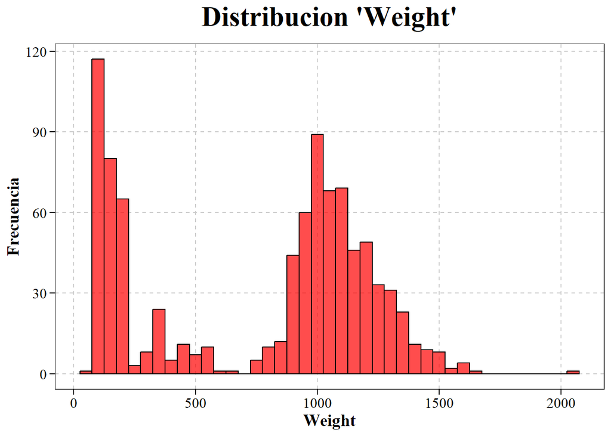

```r
ggplot(hawks_select, aes(x = Weight)) +
  geom_histogram(binwidth = 50, color= "black", fill= "red", alpha = 0.7) +
  mi_tema() +
  labs(title = "Distribucion 'Weight'", x = "Weight", y = "Frecuencia")
```

```r
# Histograma para 'Culmen'
print("Distribucion del tamaño del pico")
```

```
## [1] "Distribucion del tamaño del pico"
```

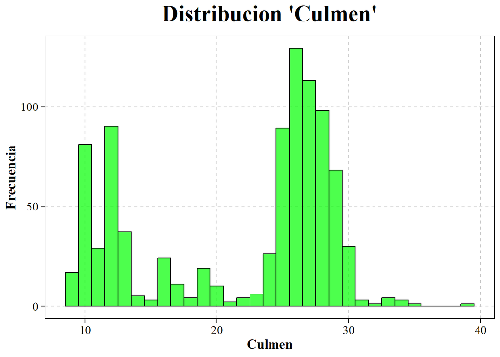

```r
ggplot(hawks_select, aes(x = Culmen)) +
  geom_histogram(binwidth = 1, color = "black", fill = "green", alpha = 0.7) +
  mi_tema() +
  labs(title = "Distribucion 'Culmen'", x = "Culmen", y = "Frecuencia")
```

```r
# Histograma para 'Hallux'
print("Distribucion del tamaño de los espolones")
```

```
## [1] "Distribucion del tamaño de los espolones"
```

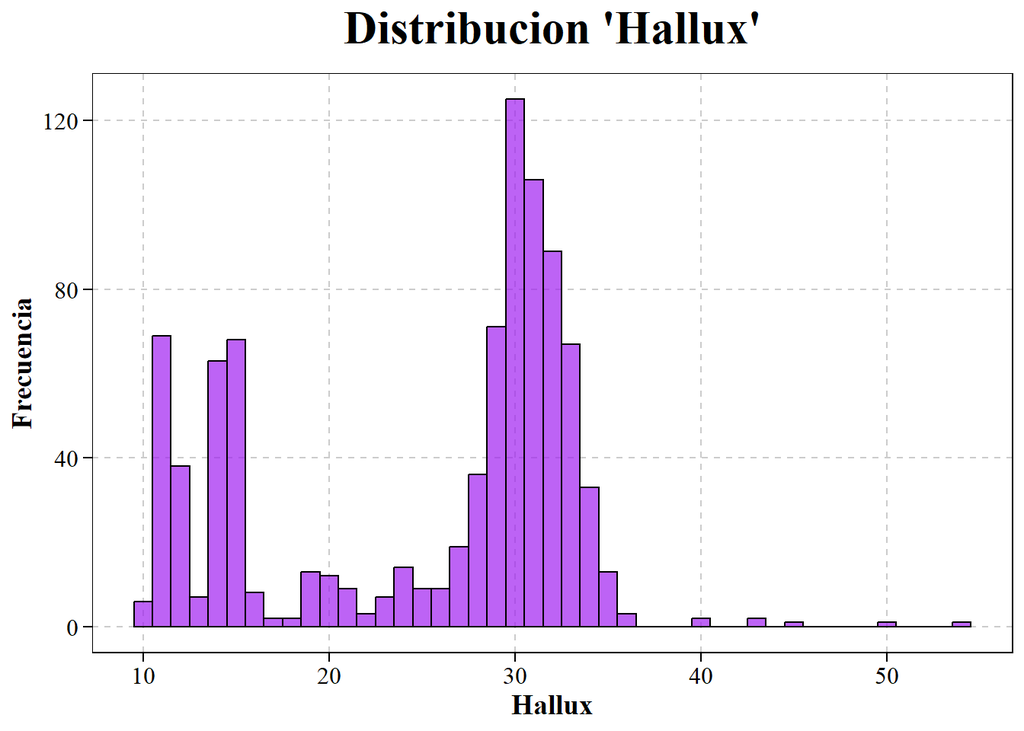

```r
ggplot(hawks_select, aes(x = Hallux)) +
  mi_tema() +
  # scale_y_log10() + # aplicamos escala logaritmica para poder representar los datos de frecuencia (y)
  # scale_x_log10() +  # aplicamos escala logaritmica para poder representar las medidas adecuadamente (x)
  geom_histogram(binwidth = 1, color = "black", fill = "purple", alpha = 0.7) +
  labs(title = "Distribucion 'Hallux'", x = "Hallux", y = "Frecuencia")
```

```r
  # labs(caption = "Escalas logatimica en base 10 en los ejes X-Y")
```

- Bar charts for categorical variables in ‘hawks_select’.

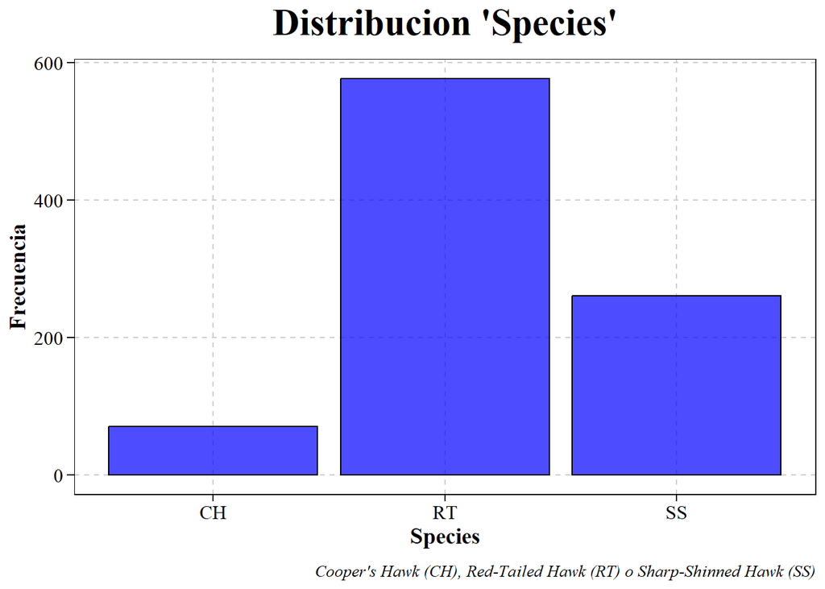

```r
## Grafico de barras para 'species' ###
#######################################

ggplot(hawks_select, aes(x= Species)) +
  mi_tema() +
  geom_bar(color= "black", fill = "blue", alpha = 0.7) +
  labs(title = "Distribucion 'Species'", x = "Species", y = "Frecuencia") +
  labs(caption = "Cooper's Hawk (CH), Red-Tailed Hawk (RT) o Sharp-Shinned Hawk (SS)")
```

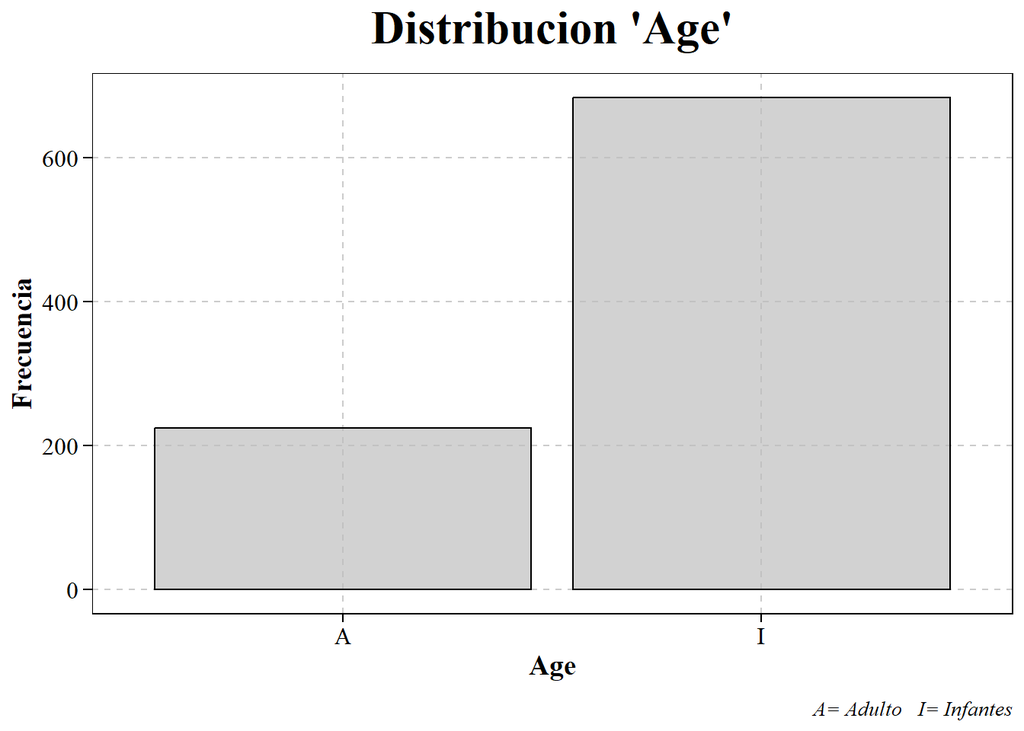

```r
## Grafico de barras para 'Age' ####
####################################

ggplot(hawks_select, aes(x = Age)) +
  geom_bar(color= "black", fill = "gray", alpha = 0.7) +
  mi_tema() +
  labs(title = "Distribucion 'Age'", x= "Age", y= "Frecuencia") +
  labs(caption = "A= Adulto   I= Infantes")
```

On the one hand, we observed an over-representation of the RT species and an under-representation of CH. On the other hand, the child population of the sample is higher than the adult population.

- Other visualisations of the variable distributions:

```r
## Distribucion de las variables numéricas ##
#############################################
print("Distribuciones de variables en la tabla 'hawks_select' \n")
```

```
## [1] "Distribuciones de variables en la tabla 'hawks_select' \n"
```

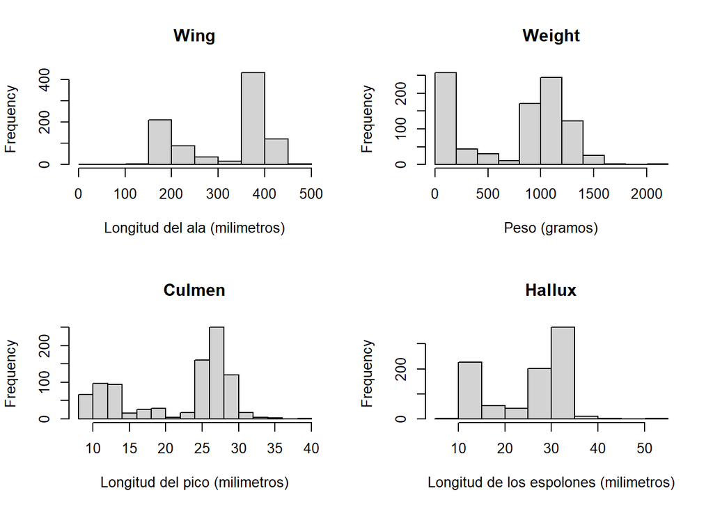

```r
# Establecemos las opciones gráficas con `par()` y con `mfrow()`configuramos la matriz de representacion
par(mfrow = c(2,2))

hist(hawks_select$Wing, main= "Wing", xlab = "Longitud del ala (milimetros)")
hist(hawks_select$Weight, main = "Weight", xlab = "Peso (gramos)")
hist(hawks_select$Culmen, main = "Culmen", xlab = "Longitud del pico (milimetros)")
hist(hawks_select$Hallux, main = "Hallux", xlab = "Longitud de los espolones (milimetros)")
```

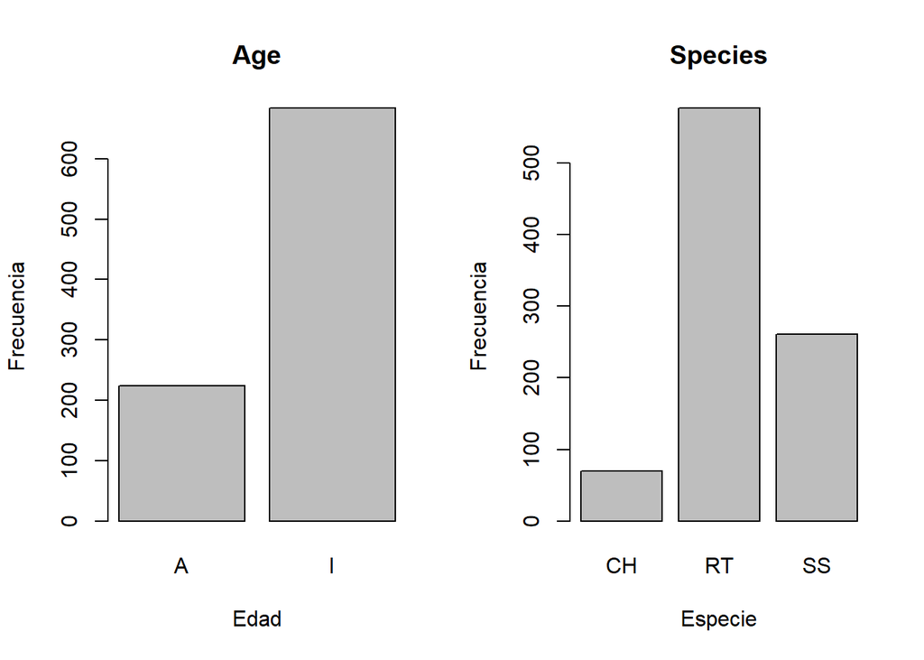

```r
## Distribucion de las variables categóricas ##
###############################################

# Restablecemos las opciones gráficas con `par()` y con `mfrow()`configuramos la matriz de representación para el tipo de grafico "Barplot"
par(mfrow = c(1,2))


barplot(table(hawks_select$Age), main = "Age", xlab = "Edad", ylab = "Frecuencia")
barplot(table(hawks_select$Species), main = "Species", xlab = "Especie", ylab = "Frecuencia")
```

### 2.1.4 Distribution of variables in annexed tables - averages according to age and species

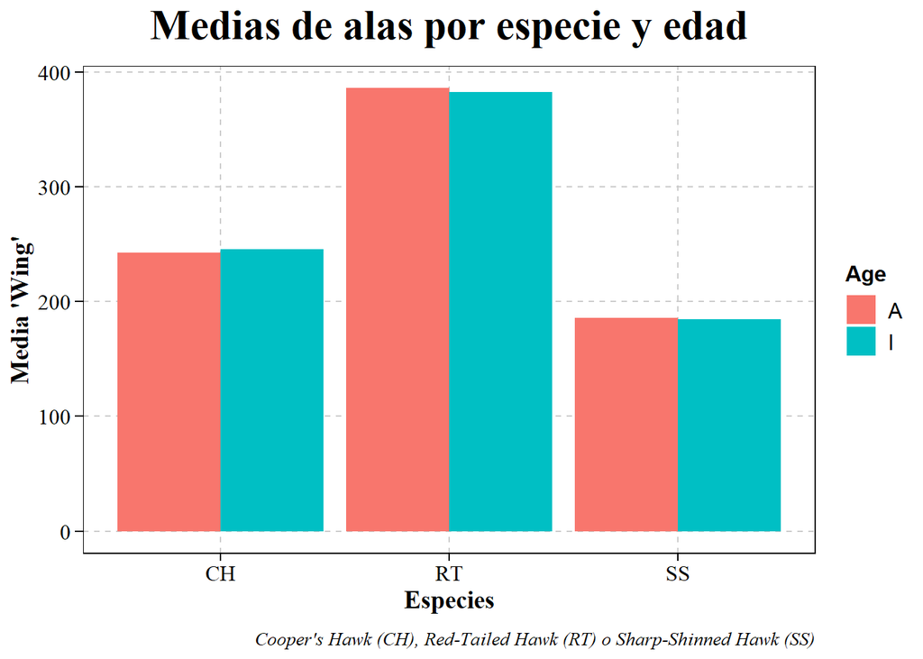

```r
## Grafica de barras agrupadas para 'media_alas_especie_edad' ##
#################################################################

ggplot(media_alas_especie_edad, aes(x = Species, y = Wing, fill= Age)) +
  mi_tema() +
  geom_bar(stat = "identity", position = "dodge") +
  labs(title = "Medias de alas por especie y edad", x = "Especies", y = "Media 'Wing'") +
  labs(caption = "Cooper's Hawk (CH), Red-Tailed Hawk (RT) o Sharp-Shinned Hawk (SS)")
```

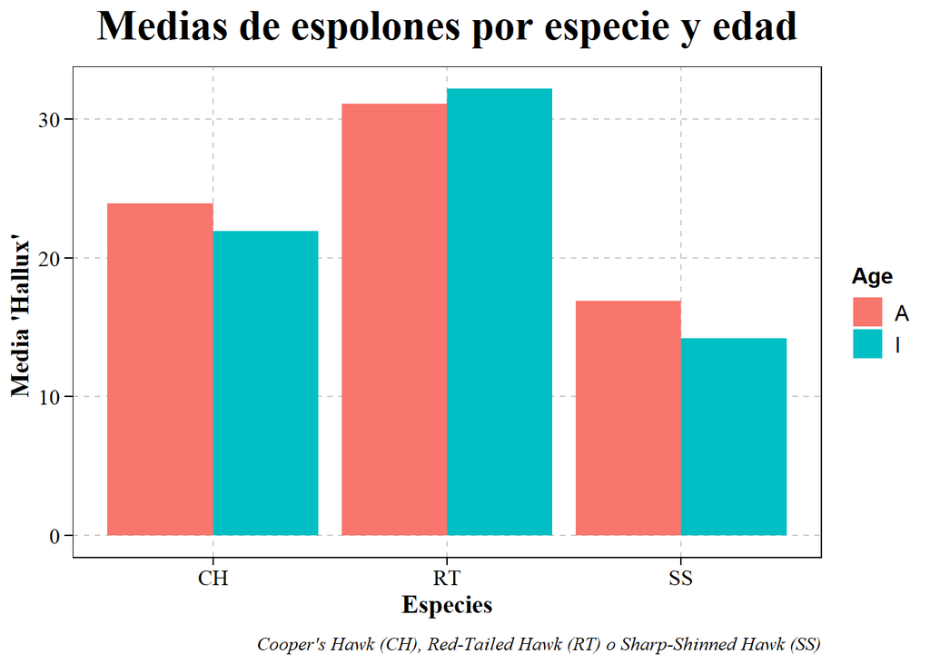

```r
## Grafica de barras agrupadas para 'media_espolon_especie_edad' ##
###################################################################

ggplot(media_espolon_especie_edad, aes(x = Species, y= Hallux, fill = Age)) +
  mi_tema() +
  geom_bar(stat= "identity", position = "dodge") +
  labs(title = "Medias de espolones por especie y edad", x = "Especies", y= "Media 'Hallux' ") +
  labs(caption = "Cooper's Hawk (CH), Red-Tailed Hawk (RT) o Sharp-Shinned Hawk (SS)")
```

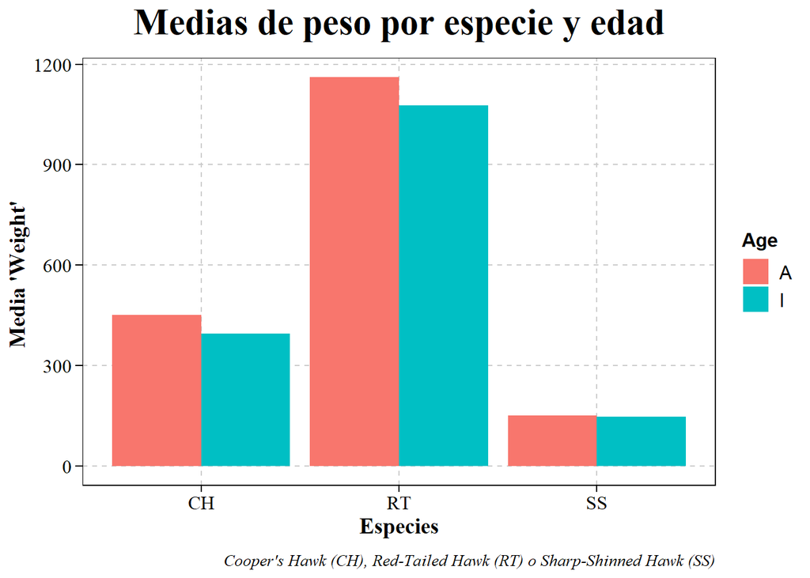

```r
## Grafica de barras agrupadas para 'media_peso_especie_edad' ##
###################################################################

ggplot(media_peso_especie_edad, aes(x = Species, y= Weight, fill = Age)) +
  mi_tema() +
  geom_bar(stat= "identity", position = "dodge") +
  labs(title = "Medias de peso por especie y edad", x = "Especies", y= "Media 'Weight' ") +
  labs(caption = "Cooper's Hawk (CH), Red-Tailed Hawk (RT) o Sharp-Shinned Hawk (SS)")
```

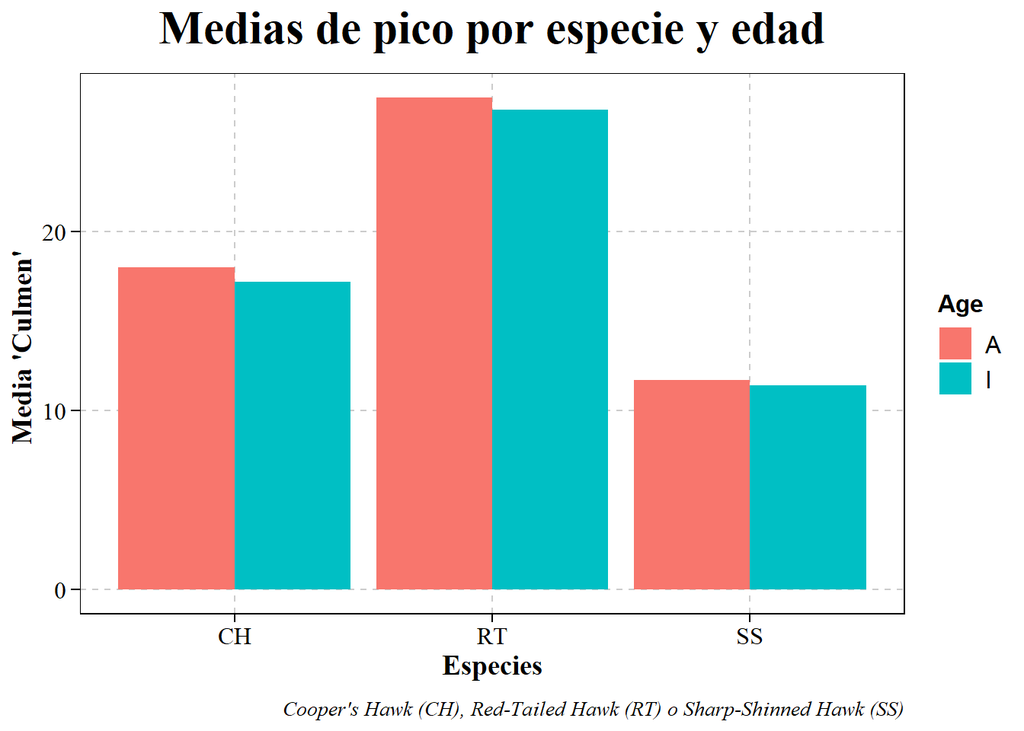

```r
## Grafica de barras agrupadas para 'media_pico_especie_edad' ##
###################################################################

ggplot(media_pico_especie_edad, aes(x = Species, y= Culmen, fill = Age)) +
  mi_tema() +
  geom_bar(stat= "identity", position = "dodge") +
  labs(title = "Medias de pico por especie y edad", x = "Especies", y= "Media 'Culmen' ") +
  labs(caption = "Cooper's Hawk (CH), Red-Tailed Hawk (RT) o Sharp-Shinned Hawk (SS)")
```

### 2.1.5 Study using k-means aggregation method

Using the ‘hawks_select’ table, where we have selected the relevant variables for our study, we will employ the k-means clustering method. This method will group observations into ‘k’ clusters based on the nearest mean. It is an unsupervised clustering method used when there are no pre-defined labels for the data (James et al. 2013; Gareth et al. 2013; Cannon et al. 2013b).

By “no pre-defined labels,” we mean that the data does not have a predetermined category or class assigned to it. In other words, we do not know which group each data point belongs to, as there are no right or wrong answers in the variable(s) Gironés Roig (2017) .

The most common uses of this technique are in segmentation - e.g., customers, to understand their needs -, dimensionality reduction - or to group into smaller clusters -, data understanding - to improve data representation -, defect or problem detection - e.g., outliers or when there are values far from the mean and logic -, and classification - after applying the algorithm, labels can be assigned.

The main objectives, but not exclusive, for applying this algorithm in this case would be:

1. Segmentation: Although we already know the labels - CH, RT, SS -, we can explore if these species have notable differences in their characteristics and if coherent data groups are formed. It will also allow us to gain a better understanding of the data and identify potential subgroups.
2. Analysis of physical characteristics and age: Clustering will reveal differences between adults and immature individuals.
3. Problem detection: By applying the summary() function earlier, we suspected the presence of possible outliers or extreme values. With this algorithm, we can confirm or dismiss this hypothesis.

#### 2.1.5.1 Application of the k-means method to the numerical variables in the ‘hawks_select’ dataset

```r
print("Aplicando k-means")
```

```
## [1] "Aplicando k-means"
```

```r
# Preprocesamiento de los datos: z-score #
##########################################

hawks_z <- scale(hawks_select[, c("Wing", "Weight", "Culmen", "Hallux")])

# Aplicamos k-means con 3 agrupaciones:

  # La semilla se fija para reproducibilidad. el valor inicializa el RNG. Si se mantiene constante, aunque el k-means use numeros aleatorios, se garantiza que se puede reproducir

# Aplicamos los k-means:

print("para tres grupos")
```

```
## [1] "para tres grupos"
```

```r
set.seed(131)

tres_grupos <- 3
kmeans3_result <- kmeans(hawks_z, centers = tres_grupos)

print("para seis grupos")
```

```
## [1] "para seis grupos"
```

```r
set.seed(131)
seis_grupos <- 6
kmeans6_result <- kmeans(hawks_z, centers = seis_grupos)

# Agregamos la información de los clusteres a los datos de la tabla original:

hawks_select$Cluster3 <- as.factor(kmeans3_result$cluster)
hawks_select$Cluster6 <- as.factor(kmeans6_result$cluster)
```

Next, we will visualize each combination of variables and the corresponding results for analysis:

- Graphs for 3 groups:

```r
print("Graficando k-means para tres grupos")
```

```
## [1] "Graficando k-means para tres grupos"
```

```r
# Tres grupos #
###############

# Wing vs Weight
print("Tres grupos: Wing vs Weight")
```

```
## [1] "Tres grupos: Wing vs Weight"
```

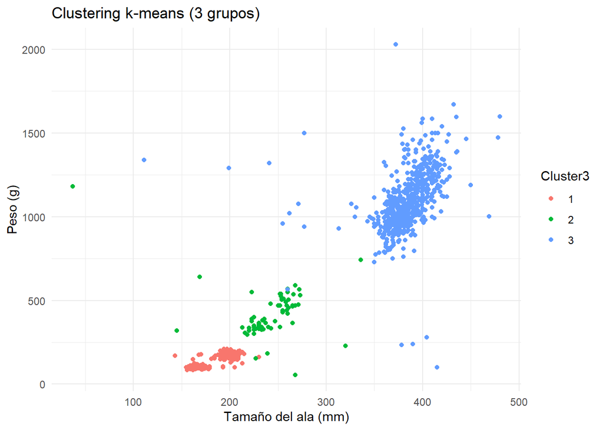

```r
ggplot(hawks_select, aes(x = Wing, y = Weight, color = Cluster3)) +
  geom_point() +
  labs(title = "Clustering k-means (3 grupos)", x = "Tamaño del ala (mm)", y = "Peso (g)") +
  theme_minimal()
```

```r
# Wing vs Culmen
print("Tres grupos: Wing vs Culmen")
```

```
## [1] "Tres grupos: Wing vs Culmen"
```

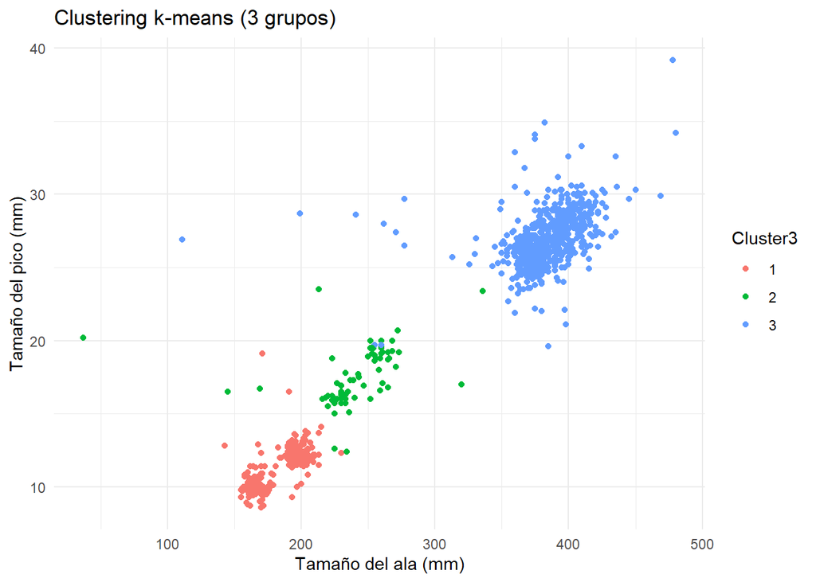

```r
ggplot(hawks_select, aes(x = Wing, y = Culmen, color = Cluster3)) +
  geom_point() +
  labs(title = "Clustering k-means (3 grupos)", x = "Tamaño del ala (mm)", y = "Tamaño del pico (mm)") +
  theme_minimal()
```

```r
# Wing vs Hallux
print("Tres grupos: Wing vs Hallux")
```

```
## [1] "Tres grupos: Wing vs Hallux"
```

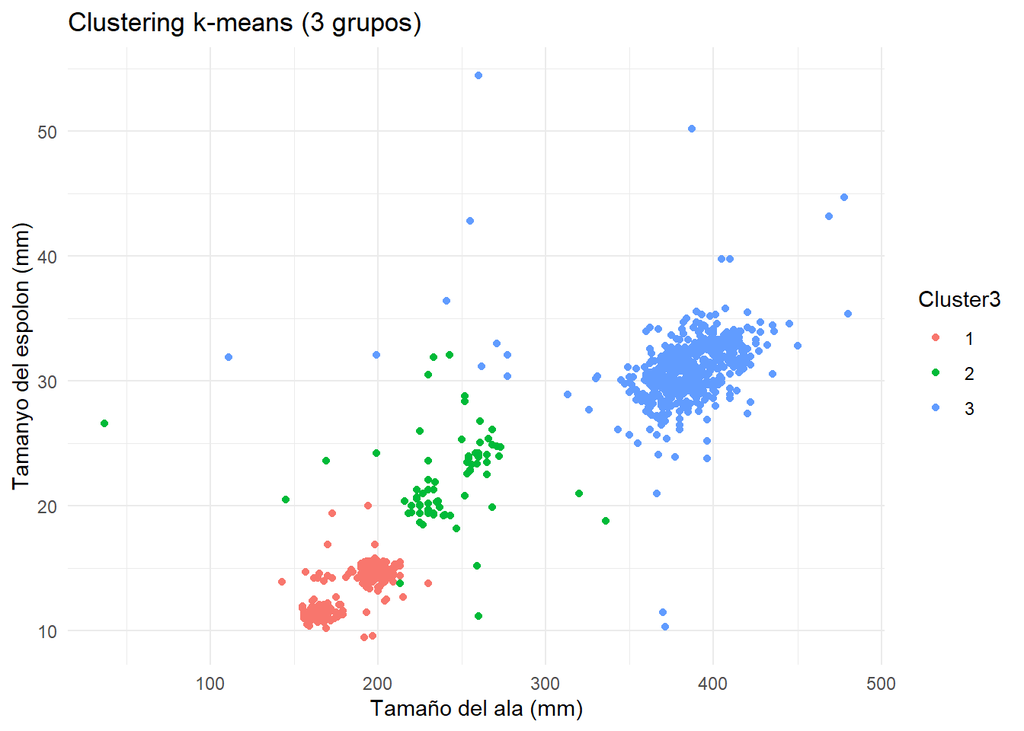

```r
ggplot(hawks_select, aes(x = Wing, y = Hallux, color = Cluster3)) +
  geom_point() +
  labs(title = "Clustering k-means (3 grupos)", x = "Tamaño del ala (mm)", y = "Tamanyo del espolon (mm)") +
  theme_minimal()
```

```r
# Weight vs Culmen
print("Tres grupos: Weight vs Culmen")
```

```
## [1] "Tres grupos: Weight vs Culmen"
```

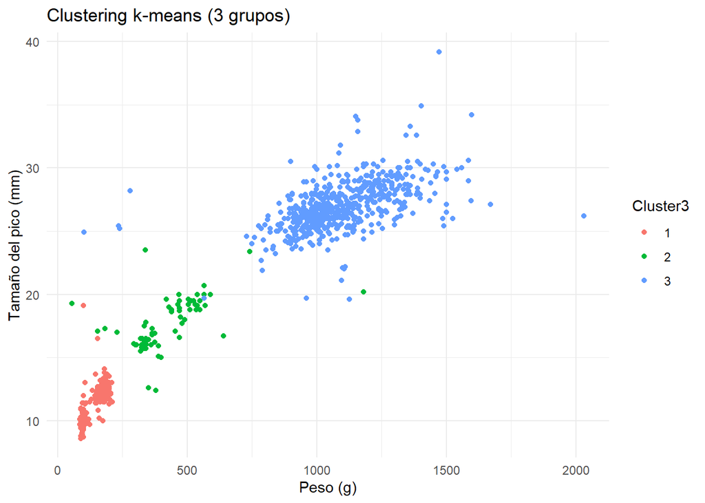

```r
ggplot(hawks_select, aes(x = Weight, y = Culmen, color = Cluster3)) +
  geom_point() +
  labs(title = "Clustering k-means (3 grupos)", x = "Peso (g)", y = "Tamaño del pico (mm)") +
  theme_minimal()
```

```r
# Weight vs Hallux
print("Tres grupos: Weight vs Hallux")
```

```
## [1] "Tres grupos: Weight vs Hallux"
```

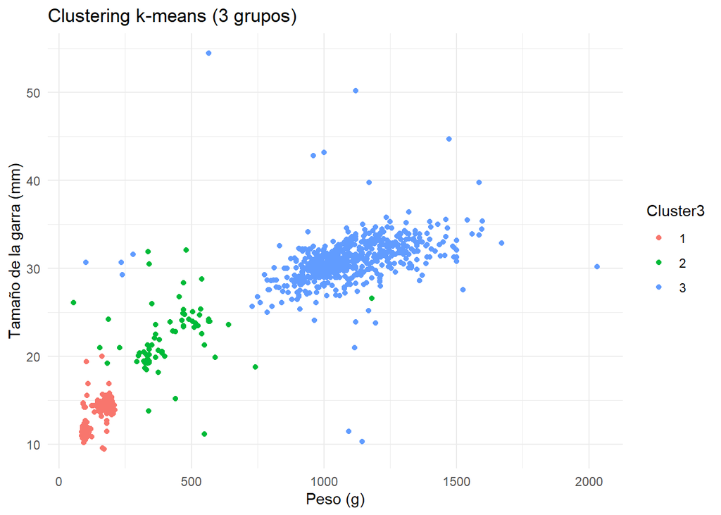

```r
ggplot(hawks_select, aes(x = Weight, y = Hallux, color = Cluster3)) +
  geom_point() +
  labs(title = "Clustering k-means (3 grupos)", x = "Peso (g)", y = "Tamaño de la garra (mm)") +
  theme_minimal()
```

```r
# Culmen vs Hallux
print("Tres grupos: Culmen vs Hallux")
```

```
## [1] "Tres grupos: Culmen vs Hallux"
```

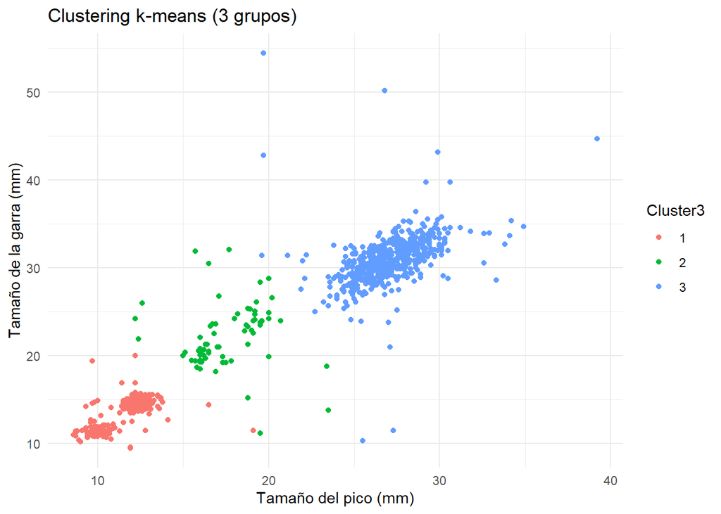

```r
ggplot(hawks_select, aes(x = Culmen, y = Hallux, color = Cluster3)) +
  geom_point() +
  labs(title = "Clustering k-means (3 grupos)", x = "Tamaño del pico (mm)", y = "Tamaño de la garra (mm)") +
  theme_minimal()
```

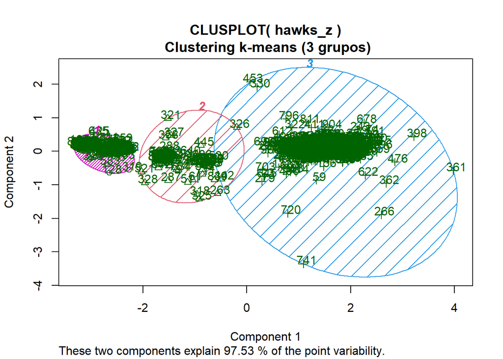

```r
# Visualizamos los clusters #
#############################

# cluster 3 #
#############

clusplot(hawks_z, kmeans3_result$cluster, color=TRUE, shade=TRUE, labels=2, lines=0)
title("\n \n Clustering k-means (3 grupos)")
```

The measurements of ‘wing’ and ‘Culmen’, that is, beak and wings, appear to tend to separate the three bird species. Weight also does not seem to be the most consistent grouping measure, as there is a lot of overlap. In general, it tends to mix observations. We assume that the problem is the mixing of juvenile and adult populations.

Charts for 6 groups:

```r
print("Graficando k-means para seis grupos")
```

```
## [1] "Graficando k-means para seis grupos"
```

```r
# Seis grupos#
##############

# Wing vs Weight
print("Seis grupos: Wing vs Weight")
```

```
## [1] "Seis grupos: Wing vs Weight"
```

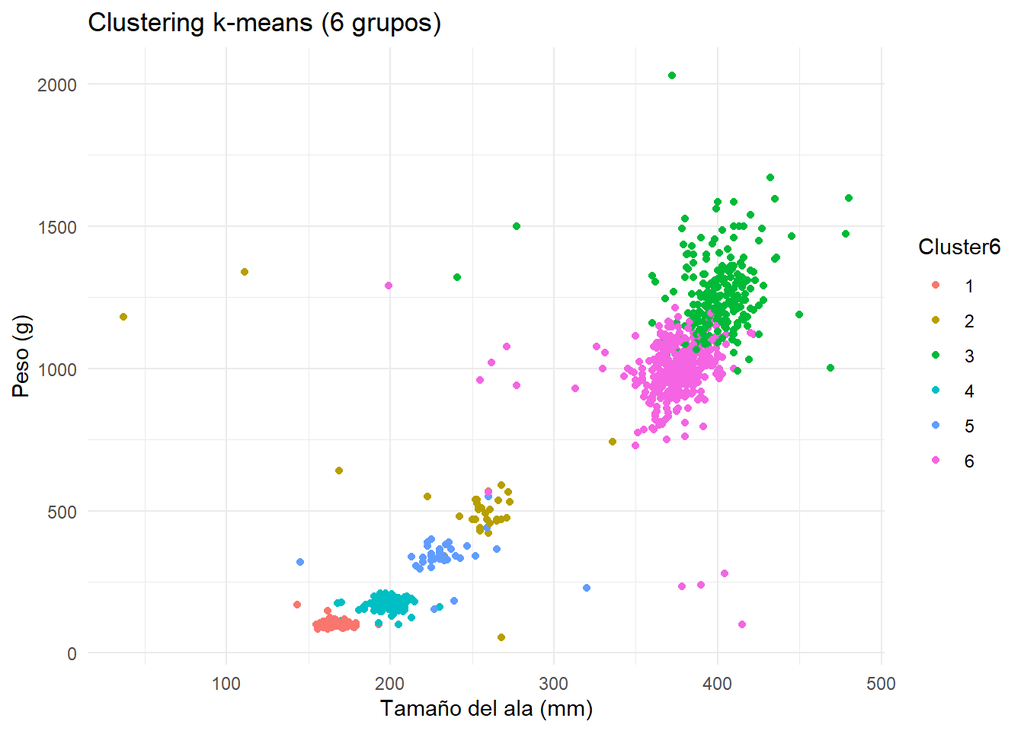

```r
ggplot(hawks_select, aes(x = Wing, y = Weight, color = Cluster6)) +
  geom_point() +
  labs(title = "Clustering k-means (6 grupos)", x = "Tamaño del ala (mm)", y = "Peso (g)") +
  theme_minimal()
```

```r
# Wing vs Culmen
print("Seis grupos: Wing vs Culmen")
```

```
## [1] "Seis grupos: Wing vs Culmen"
```

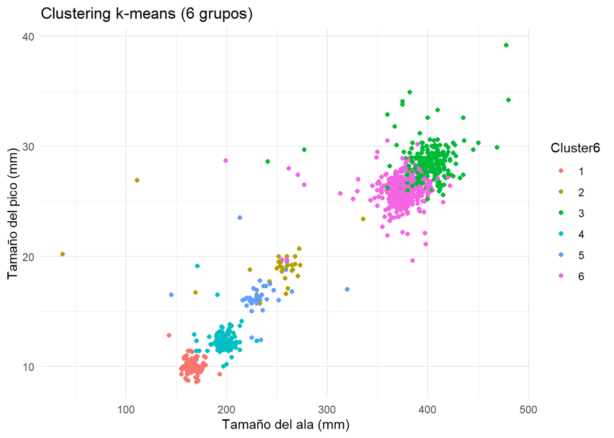

```r
ggplot(hawks_select, aes(x = Wing, y = Culmen, color = Cluster6)) +
  geom_point() +
  labs(title = "Clustering k-means (6 grupos)", x = "Tamaño del ala (mm)", y = "Tamaño del pico (mm)") +
  theme_minimal()
```

```r
# Wing vs Hallux
print("Seis grupos: Wing vs Hallux")
```

```
## [1] "Seis grupos: Wing vs Hallux"
```

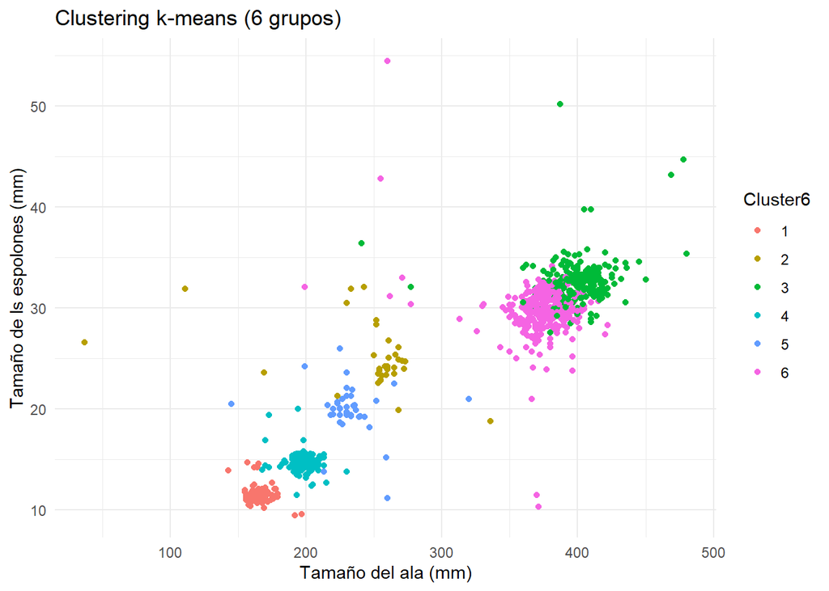

```r
ggplot(hawks_select, aes(x = Wing, y = Hallux, color = Cluster6)) +
  geom_point() +
  labs(title = "Clustering k-means (6 grupos)", x = "Tamaño del ala (mm)", y = "Tamaño de ls espolones (mm)") +
  theme_minimal()
```

```r
# Weight vs Culmen
print("Seis grupos: Weight vs Culmen")
```

```
## [1] "Seis grupos: Weight vs Culmen"
```

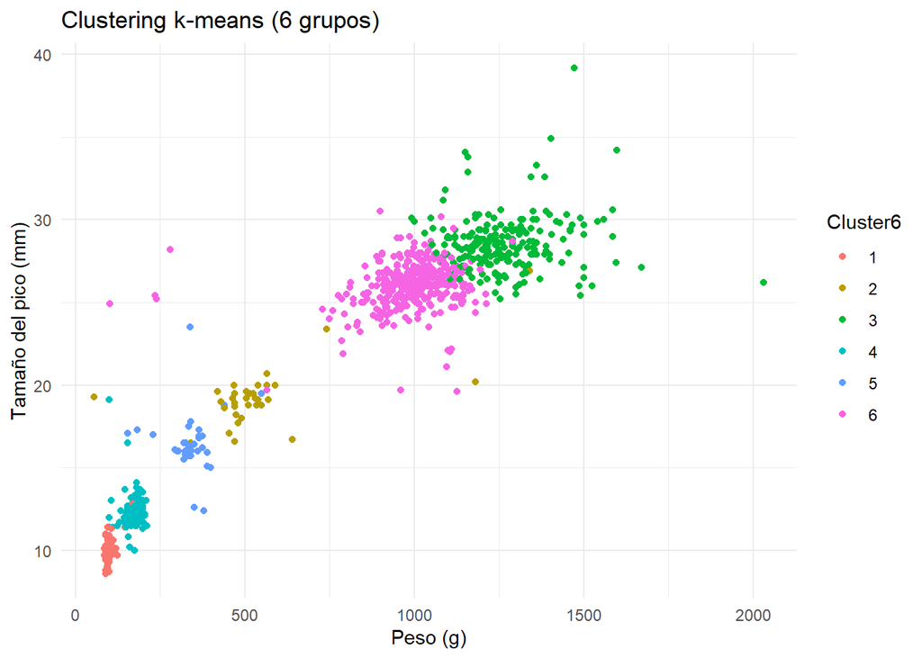

```r
ggplot(hawks_select, aes(x = Weight, y = Culmen, color = Cluster6)) +
  geom_point() +
  labs(title = "Clustering k-means (6 grupos)", x = "Peso (g)", y = "Tamaño del pico (mm)") +
  theme_minimal()
```

```r
# Weight vs Hallux
print("Seis grupos: Weight vs Hallux")
```

```
## [1] "Seis grupos: Weight vs Hallux"
```

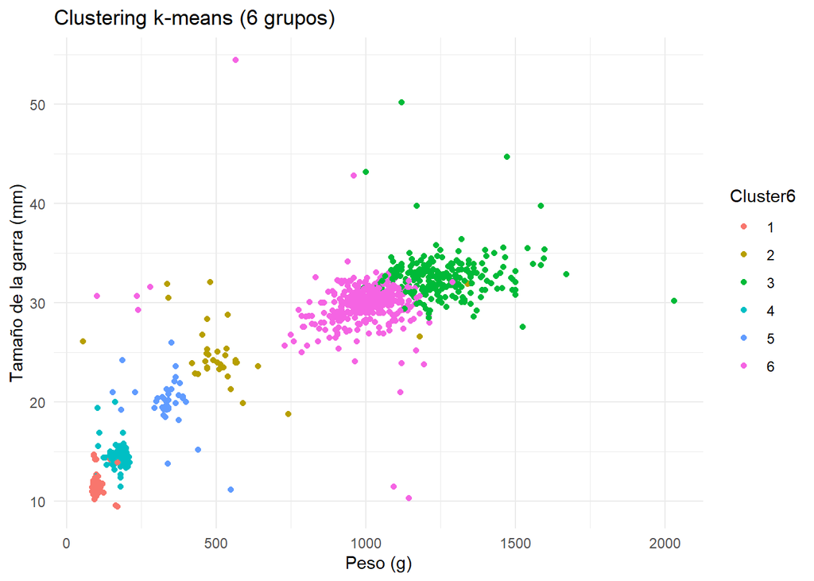

```r
ggplot(hawks_select, aes(x = Weight, y = Hallux, color = Cluster6)) +
  geom_point() +
  labs(title = "Clustering k-means (6 grupos)", x = "Peso (g)", y = "Tamaño de la garra (mm)") +
  theme_minimal()
```

```r
# Culmen vs Hallux
print("Seis grupos: Culmen vs Hallux")
```

```
## [1] "Seis grupos: Culmen vs Hallux"
```

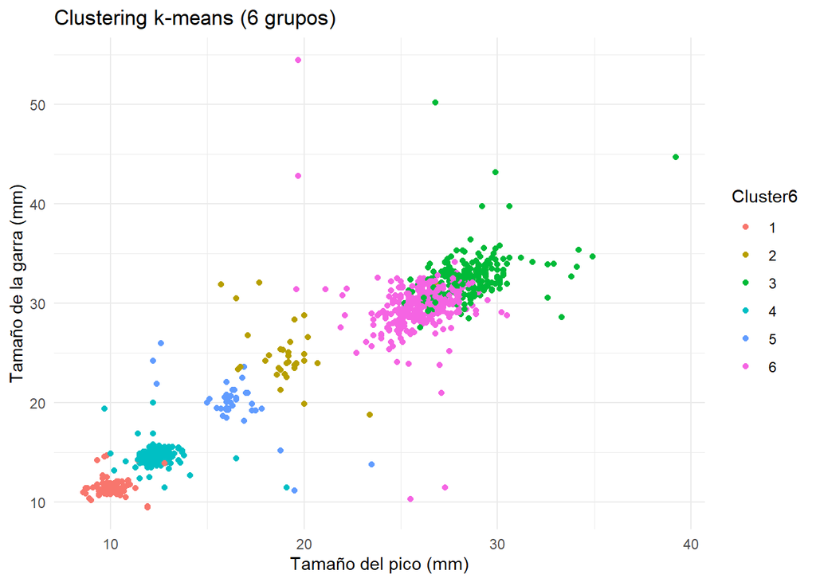

```r
ggplot(hawks_select, aes(x = Culmen, y = Hallux, color = Cluster6)) +
  geom_point() +
  labs(title = "Clustering k-means (6 grupos)", x = "Tamaño del pico (mm)", y = "Tamaño de la garra (mm)") +
  theme_minimal()
```

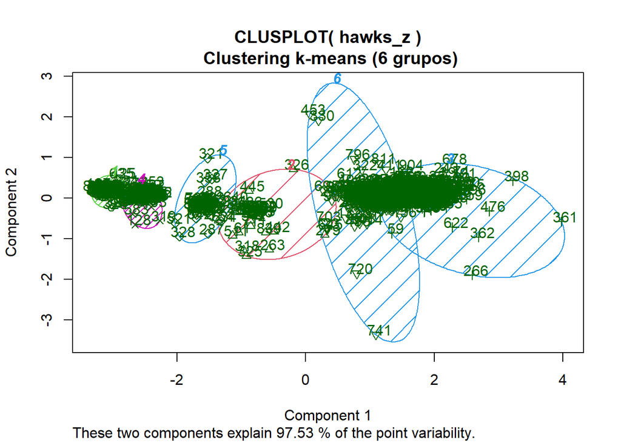

```r
# Visualizamos los clusters #
#############################


# cluster 6 #
############

clusplot(hawks_z, kmeans6_result$cluster, color=TRUE, shade=TRUE, labels=2, lines=0)
title("\n \n Clustering k-means (6 grupos)")
```

We observe that forcing the creation of 6 groups does not result in convincing outcomes. In general, everything suggests that there are 3 groups, although not very homogeneous, which tend to mix and confuse the algorithm when trying to group them.

#### 2.1.5.2 Analysis of the results

At this point, as we have observed throughout, the graphs of the different variables suggest the existence of 3 groups, although not very homogeneous. Ideally, we would have been able to make the clusters comparable across different age groups and species by including age as an analytical variable. However, the k-means algorithm is designed to work with continuous variables, and both species and age are categorical.

One possible solution that was not addressed at the beginning of this exercise would have been to create indicator variables (dummy variables) with values of 1 and 0. However, this approach would have also brought problems, as k-means assigns equal importance to all variables, and the indicator variables would have played an inappropriate role in the analysis. Additionally, the analysis seemed much more complex with dummy variables.

Since we still do not have a clear idea of how many groups we can label the data with, we will try to perform hierarchical clustering. Given the nature of the dataset, we made the mistake of assuming that we could guess the number of clusters based on the nature of the data. Therefore, we will attempt to use hierarchical clustering based on the Euclidean method.

```r
print("clustering jerarquico")
```

```
## [1] "clustering jerarquico"
```

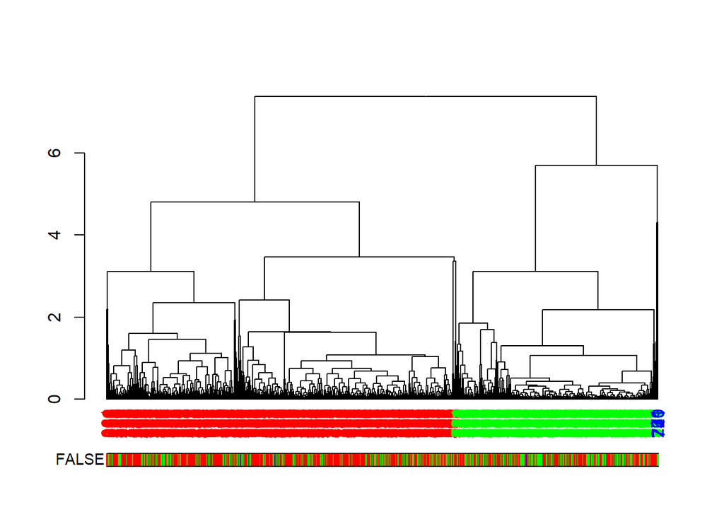

```r
# Calculamos la matriz de distancias
distancias <- dist(hawks_z, method = "euclidean")

# Realizamos el clustering jerárquico
clustering_jerarquico <- hclust(distancias, method = "complete")

# Cortamos el árbol para obtener 3 clusters
clusters_jerarquico3 <- cutree(clustering_jerarquico, k = 3)

# Añadimos la información de los clusters al data frame original
hawks_select$ClusterH3 <- as.factor(clusters_jerarquico3)

# Visualizamos el dendrograma
dend <- as.dendrogram(clustering_jerarquico)
# Coloreamos las ramas del dendrograma según los grupos
colors <- rainbow(3)[clusters_jerarquico3]
labels_colors(dend) <- colors[order.dendrogram(dend)]
plot(dend)
colored_bars(colors[order.dendrogram(dend)], dend, rowLabels = FALSE)
```

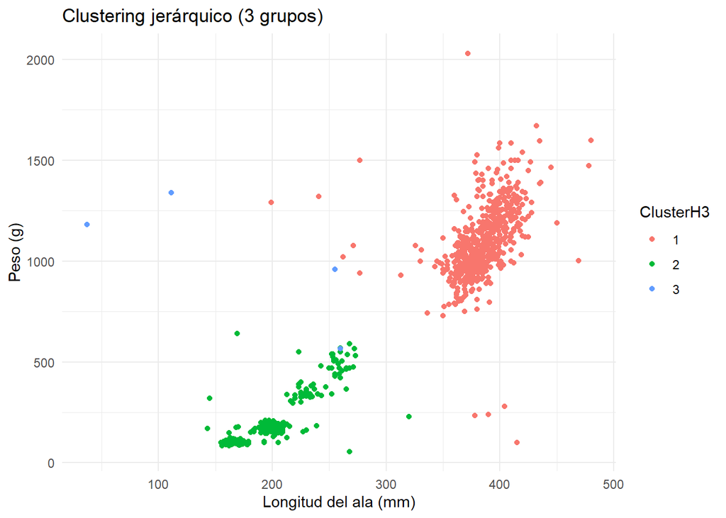

```r
# Graficamos un ejemplo de dispersión para los clusters jerárquicos
ggplot(hawks_select, aes(x = Wing, y = Weight, color = ClusterH3)) +
  geom_point() +
  labs(title = "Clustering jerárquico (3 grupos)", x = "Longitud del ala (mm)", y = "Peso (g)") +
  theme_minimal()
```

```r
# visualizamos la tabla con la agrupacion de los resultados:
table(clusters_jerarquico3)
```

```
## clusters_jerarquico3
##   1   2   3
## 576 328   4
```